# Report

Mehrad Haghshenas

2022-12-20

### Research Question

**How precise can the quality of wine be predicted based on the following attributes: “fixed acidity”, “volatile acidity”, “citric acid”, “residual sugar”, “chlorides”, “free sulfur dioxide”, “total sulfur dioxide”, “density”, “pH”, “sulphates”, and “alcohol”?**

### Introduction

The project aims to examine multiple machine learning models where the response is the quality of wine and the predictors are the mentioned variables. The goal is to find the *best* model for prediction and inference of the quality of wine. By doing so, certification entities, wine producers, and even consumers can benefit from such a model. For this aim, two data sets have been used:

- The first data set is the “red.csv” data set which consists of “red wines”.
- The second data set is the “white.csv” data set consisting of “white wines”.

These data sets were publicly donated on the 7th of October 2009 and are the two most common variants, white and red (rosé is also produced), from the demarcated Portuguese region of vinho verde. Both have 12 columns; namely, *fixed acidity, volatile acidity, citric acid, residual sugar, chlorides, free sulfur dioxide, total sulfur dioxide, density, pH, sulphates, alcohol, quality.* The *red wine* data set has 1599 **observations**, whereas the *white wine* data set has 4898 **observations**. In the proposal it is written that the data sets contain 1600 rows and 4899 rows respectively. This is because the first row of the data sets are the names of each column. The data were collected from May of 2004 to February of 2007 using only protected designation of origin samples that were tested at the official certification entity (CVRVV). Moreover, this wine accounts for 15% of the total Portuguese production during that time, making this data set large compared to other data sets prepared in this domain. Both data sets can be found on the following website: [UCI (University of California, Irvine), Center for Machine Learning & Intelligent Systems](https://archive.ics.uci.edu/ml/datasets/wine+quality)

In brief, the task is creating a model to predict the quality of a wine based on the given attributes. In other words, the data sets can be viewed as classification and regression problems. The intention is to answer the following questions:

- *Feature selection*: Which attributes contribute the most to the quality of wine?
  - Selection methods will be used to see whether all input variables are relevant to the quality of the wine. Seeing the predictors, particularly, *fixed acidity*, *volatile acidity*, and *citric acid*, they seem to be correlated. *Free sulfur dioxide* and *total sulfur dioxide* seem to have a correlation as well. Likewise, we are not sure if all input variables are relevant. Therefore, it could be interesting to test feature selection methods.
- *Prediction*: Which machine learning model will give better prediction for the quality of wine?
- *Inference*: Which model will given better intuition for predicting the quality of wine?

To answer these questions, several machine learning models will be applied on the two data sets separately and the results will be compared to each other. We will also see how the models differ for white wine and red wine; specifically, are there any attributes that is more *influential* for the quality of red wine which is not for white wine (or vice versa)?

The list below are the regression machine learning models applied on the data sets. The first one is a linear regression model. Moving on, in the second part, the model is a non-parametric non-linear model (trees). Although, they are less intuitive, they might have higher prediction accuracy. These assumptions will be tested however, with further analysis.

- **multiple linear regression & subset selection linear regression (best subset, forward step-wise, backward step-wise, sequential step-wise)**
- **regression decision trees & tree ensemble methods: bagging and random forests**

In addition, classification techniques will be applied on the data sets. Note that the quality of wine in both data sets is a quantitative variable with integer values ranging from 0 (poor quality) to 10 (excellent quality). However, these values can be treated in two ways: 1 - as continuous values in a regression problem or 2 - as eleven classes for a classification problem. Moreover, in order to apply classification techniques one can apply a threshold and categorize the wines based on their *quality* value. Treating quality as an *ordinal value*, the following methods will be applied.

- **logistic regression**
- **classification decision trees & tree ensemble methods: bagging and random forests.**
- **support vector machines (SVM)**

It is worth mentioning that wine certification is generally assessed by physicochemical and sensory tests. Determination of density, alcohol or pH values, are some of the Physicochemical laboratory tests used for wine certification. With regards to sensory tests, they rely mainly on human experts (in this case, the *median* of evaluations made by at least 3 wine experts was taken for the quality score). However, it should be emphasized that the weakest sense among the five prominent human senses is *taste*. For detailed information on the *background* and *data sets*, please read the *references* and *proposal.*

### Machine Learning techniques

As the first step, we will read in the data sets.

```r
library (tidyverse)
red   <- read_csv2("red.csv")
white <- read_csv2("white.csv")
```

In the following, it can be seen that the *quality* variable has a normal distribution for the *red* and *white* data sets. In other words, there are more *normal* wine compared to excellent and very poor wine (as expected). For the *red* data set, the maximum quality is 8 and the minimum is 3. For the *white* data set, the maximum quality is 9 and the minimum is 3. Note that the *quality* variable can take any integer from a scale 0-10.

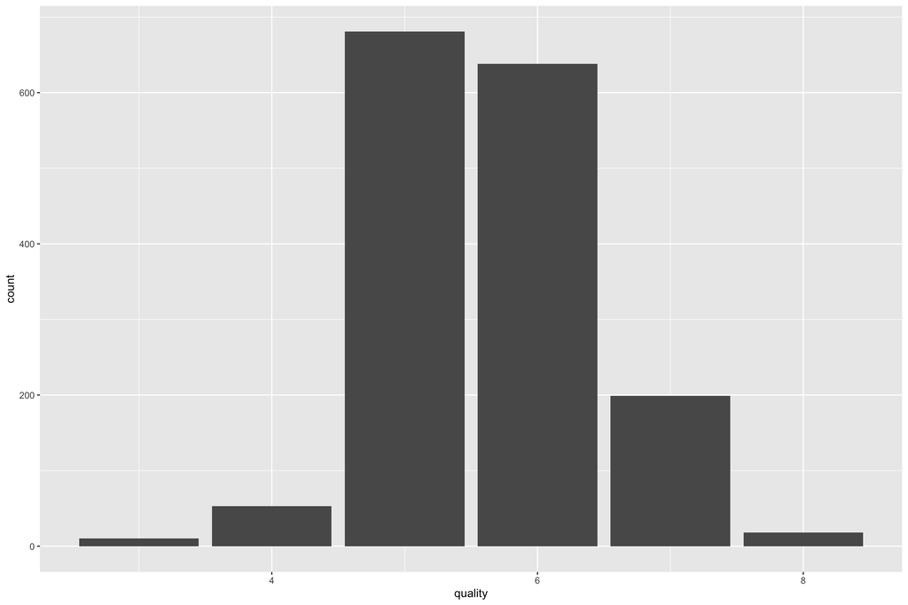

```r
ggplot(data = red) +
  geom_bar(mapping = aes(x = quality))
```

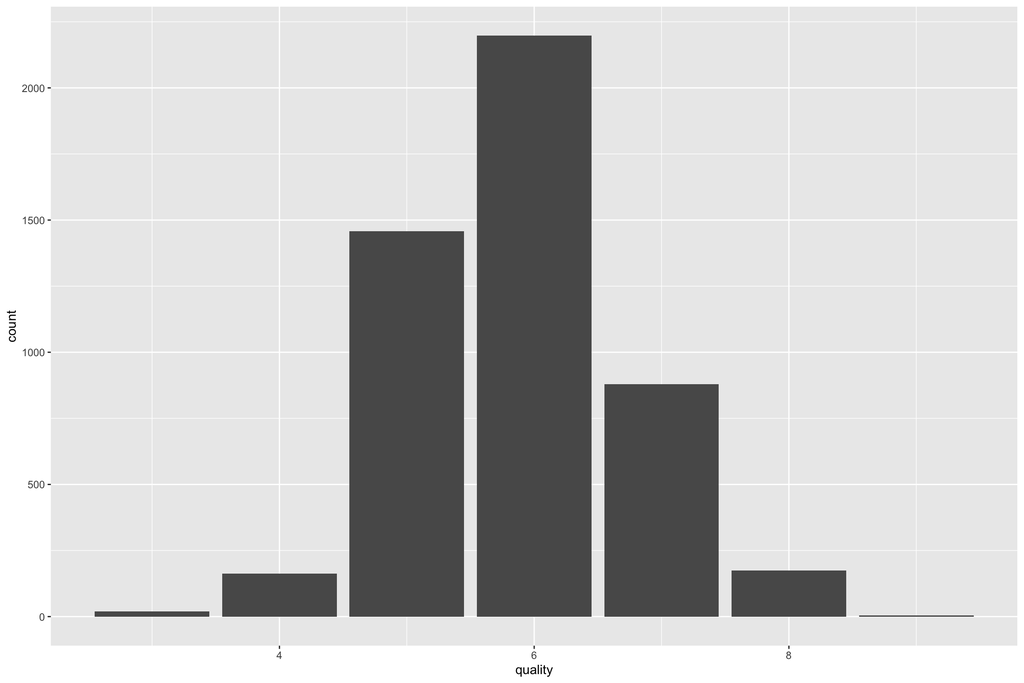

```r
ggplot(data = white) +
  geom_bar(mapping = aes(x = quality))
```

Moving on, we will see if the data sets contain any *not found* values.

```r
sapply(red, function(x) sum(is.na(x)))
##        fixed acidity     volatile acidity          citric acid
##                    0                    0                    0
##       residual sugar            chlorides  free sulfur dioxide
##                    0                    0                    0
## total sulfur dioxide              density                   pH
##                    2                    0                    0
##            sulphates              alcohol              quality
##                    0                    0                    0
```

```r
sapply(white, function(x) sum(is.na(x)))
##        fixed acidity     volatile acidity          citric acid
##                    0                    0                    0
##       residual sugar            chlorides  free sulfur dioxide
##                    0                    0                    0
## total sulfur dioxide              density                   pH
##                    0                    0                    0
##            sulphates              alcohol              quality
##                    0                    0                    0
```

As seen the white data set has no *NA* values where as in the red data set two *NA* values can be seen in the *total sulfur dioxide* column. The two data records containing a *null* value for the total sulfur dioxide column can be neglected given the large number of observations. In other words, when having 1600 observations, two observations can be excluded without any particular loss of information. So we exclude them from the red data set regardless of whether total sulfur dioxide is an influential predictor or not.

```r
red <- na.omit(red)
```

Furthermore, looking at the scale of the predictors they are not all on the same scale. As an example, this can be seen in variables *chlorides* and *fixed acidity*:

```r
min(red$chlorides)
## [1] "0.012"
max(red$chlorides)
## [1] "0.611"
min(red$`fixed acidity`)
## [1] 5
max(red$`fixed acidity`)
## [1] 159
```

Hence, before applying any machine learning methods, we will feature scale the predictors. By doing so, our models will converge much faster. More importantly, the variables which have larger values do not impact the prediction more than the variables with smaller values. For feature scaling, *standardization* will be used. Before standardizing, all the values of the data set will be converted to numerical values (although all the values are already numerical, but some have been saved as *char* data type. So, further type casting is needed to convert them to numeric data types). Ultimately, take note that it is not needed to scale the response variable (unless you are dealing with very large responses like GPU linear algebra [Is It Necessary to Scale the Target Value in Addition to Scaling Features for Regression Analysis?, 2014](https://stats.stackexchange.com/questions/111467/is-it-necessary-to-scale-the-target-value-in-addition-to-scaling-features-for-re)). In our data set, the response is not large and thus will not be feature scaled. Having said that, it can be scaled if one wishes; nonetheless, in general, when applying feature scaling, the *interpretation* of the model becomes harder. Therefore, where there is no need, it is recommended to not feature scale.

```r
red <- as.tibble(sapply(red, as.numeric))
white <- as.tibble(sapply(white, as.numeric))
red <- cbind(scale(red[,-ncol(red)]),red[,ncol(red)])
white <- cbind(scale(white[,-ncol(white)]),white[,ncol(white)])
```

If you look at the summary of the data set now, you can see that each variable has a mean and standard deviation of 0 and 1 respectively:

```
##  fixed acidity      volatile acidity   citric acid      residual sugar
##  Min.   :-2.02259   Min.   :-1.9668   Min.   :-2.7615   Min.   :-1.1418
##  1st Qu.:-0.04967   1st Qu.:-0.6770   1st Qu.:-0.5304   1st Qu.:-0.9250
##  Median : 0.16172   Median :-0.1810   Median :-0.1173   Median :-0.2349
##  Mean   : 0.00000   Mean   : 0.0000   Mean   : 0.0000   Mean   : 0.0000
##  3rd Qu.: 0.37310   3rd Qu.: 0.4143   3rd Qu.: 0.4612   3rd Qu.: 0.6917
##  Max.   :22.99123   Max.   : 8.1528   Max.   :10.9553   Max.   :11.7129
##    chlorides       free sulfur dioxide total sulfur dioxide    density
##  Min.   :-1.6831   Min.   :-0.59860    Min.   :-0.90842     Min.   :-2.31280
##  1st Qu.:-0.4473   1st Qu.:-0.27634    1st Qu.:-0.26434     1st Qu.:-0.77063
##  Median :-0.1269   Median :-0.10754    Median :-0.09519     Median :-0.09608
##  Mean   : 0.0000   Mean   : 0.00000    Mean   : 0.00000     Mean   : 0.00000
##  3rd Qu.: 0.1935   3rd Qu.: 0.07661    3rd Qu.: 0.12438     3rd Qu.: 0.69298
##  Max.   :13.7417   Max.   :21.85193    Max.   :22.87686     Max.   :15.02976
##        pH            sulphates          alcohol            quality
##  Min.   :-3.0856   Min.   :-2.3645   Min.   :-0.05257   Min.   :3.000
##  1st Qu.: 0.1838   1st Qu.:-0.6996   1st Qu.:-0.05257   1st Qu.:5.000
##  Median : 0.3142   Median :-0.1739   Median :-0.05257   Median :6.000
##  Mean   : 0.0000   Mean   : 0.0000   Mean   : 0.00000   Mean   :5.878
##  3rd Qu.: 0.4228   3rd Qu.: 0.5271   3rd Qu.:-0.05257   3rd Qu.:6.000
##  Max.   : 1.0310   Max.   : 5.1711   Max.   :28.00913   Max.   :9.000
##  fixed acidity      volatile acidity    citric acid       residual sugar
##  Min.   :-2.44891   Min.   :-2.27589   Min.   :-1.39360   Min.   :-0.58411
##  1st Qu.:-0.24493   1st Qu.:-0.76865   1st Qu.:-0.93132   1st Qu.:-0.22937
##  Median : 0.06992   Median :-0.04294   Median :-0.05812   Median :-0.11112
##  Mean   : 0.00000   Mean   : 0.00000   Mean   : 0.00000   Mean   : 0.00000
##  3rd Qu.: 0.55970   3rd Qu.: 0.62694   3rd Qu.: 0.76371   3rd Qu.:-0.04018
##  Max.   : 2.93859   Max.   : 5.87437   Max.   : 3.74286   Max.   :14.85879
##    chlorides        free sulfur dioxide total sulfur dioxide
##  Min.   :-1.60231   Min.   :-0.8131     Min.   :-1.2289
##  1st Qu.:-0.37074   1st Qu.:-0.4986     1st Qu.:-0.7426
##  Median :-0.17963   Median :-0.1317     Median :-0.2562
##  Mean   : 0.00000   Mean   : 0.0000     Mean   : 0.0000
##  3rd Qu.: 0.05394   3rd Qu.: 0.2352     3rd Qu.: 0.4733
##  Max.   :11.11684   Max.   :20.3618     Max.   : 7.3735
##     density                pH            sulphates          alcohol
##  Min.   :-3.537031   Min.   :-3.0668   Min.   :-1.9381   Min.   :-0.04321
##  1st Qu.:-0.608105   1st Qu.: 0.1945   1st Qu.:-0.6398   1st Qu.:-0.04321
##  Median : 0.000985   Median : 0.3299   Median :-0.2267   Median :-0.04321
##  Mean   : 0.000000   Mean   : 0.0000   Mean   : 0.0000   Mean   : 0.00000
##  3rd Qu.: 0.578296   3rd Qu.: 0.4341   3rd Qu.: 0.4225   3rd Qu.:-0.04321
##  Max.   : 3.676708   Max.   : 1.0801   Max.   : 7.9172   Max.   :28.32427
##     quality
##  Min.   :3.000
##  1st Qu.:5.000
##  Median :6.000
##  Mean   :5.637
##  3rd Qu.:6.000
##  Max.   :8.000
```

Upon standardizing the predictors, we will now run the pre-mentioned machine learning models in order:

##### multiple linear regression

The first step will be to identify whether there is a relationship between the response and predictors? In other words, are the predictors at all related to the response or not. In this situation, the *null hypothesis* will be that all coefficients are zero. The *alternative hypothesis* will be that at least one of the coefficients (not including the intercept) in the multiple linear regression model is non-zero. To answer this question, F-statistic will be used.

multiple linear regression model for red wine data set:

```r
library (ISLR2)
mlr_red <- lm (quality ~ ., data = red)
summary (mlr_red)
##
## Call:
## lm(formula = quality ~ ., data = red)
##
## Residuals:
##      Min       1Q   Median       3Q      Max
## -2.81024 -0.45262 -0.04824  0.47109  2.32619
##
## Coefficients:
##                         Estimate Std. Error t value Pr(>|t|)
## (Intercept)             5.636819   0.017155 328.589  < 2e-16 ***
## `fixed acidity`         0.020112   0.019512   1.031   0.3028
## `volatile acidity`     -0.166464   0.022709  -7.330 3.64e-13 ***
## `citric acid`           0.113264   0.024767   4.573 5.18e-06 ***
## `residual sugar`        0.025597   0.017450   1.467   0.1426
## chlorides              -0.152849   0.019366  -7.893 5.47e-15 ***
## `free sulfur dioxide`   0.084741   0.021352   3.969 7.55e-05 ***
## `total sulfur dioxide` -0.178964   0.021582  -8.292 2.35e-16 ***
## density                -0.170220   0.020285  -8.391  < 2e-16 ***
## pH                      0.005365   0.017294   0.310   0.7564
## sulphates               0.210847   0.019623  10.745  < 2e-16 ***
## alcohol                 0.038254   0.017210   2.223   0.0264 *
## ---
## Signif. codes:  0 '***' 0.001 '**' 0.01 '*' 0.05 '.' 0.1 ' ' 1
##
## Residual standard error: 0.6855 on 1585 degrees of freedom
## Multiple R-squared:  0.2847, Adjusted R-squared:  0.2797
## F-statistic: 57.35 on 11 and 1585 DF,  p-value: < 2.2e-16
```

multiple linear regression model for white wine data set:

```r
mlr_white <- lm (quality ~ ., data = white)
summary (mlr_white)
##
## Call:
## lm(formula = quality ~ ., data = white)
##
## Residuals:
##     Min      1Q  Median      3Q     Max
## -3.2979 -0.5124 -0.0288  0.4809  5.6981
##
## Coefficients:
##                         Estimate Std. Error t value Pr(>|t|)
## (Intercept)             5.877909   0.011015 533.623  < 2e-16 ***
## `fixed acidity`        -0.014940   0.011152  -1.340 0.180401
## `volatile acidity`     -0.178504   0.011269 -15.841  < 2e-16 ***
## `citric acid`           0.021048   0.011381   1.849 0.064466 .
## `residual sugar`        0.521203   0.021389  24.368  < 2e-16 ***
## chlorides              -0.043513   0.011876  -3.664 0.000251 ***
## `free sulfur dioxide`  -0.004912   0.012014  -0.409 0.682667
## `total sulfur dioxide`  0.033612   0.012131   2.771 0.005614 **
## density                -0.708321   0.022299 -31.765  < 2e-16 ***
## pH                      0.013870   0.011064   1.254 0.210061
## sulphates               0.105959   0.011236   9.431  < 2e-16 ***
## alcohol                -0.016973   0.011021  -1.540 0.123617
## ---
## Signif. codes:  0 '***' 0.001 '**' 0.01 '*' 0.05 '.' 0.1 ' ' 1
##
## Residual standard error: 0.7709 on 4886 degrees of freedom
## Multiple R-squared:  0.244,  Adjusted R-squared:  0.2423
## F-statistic: 143.4 on 11 and 4886 DF,  p-value: < 2.2e-16
```

As seen, the F-statistic (57.35) for the red data set and the F-statistic for the white data set (143.4) are much larger than 1 indicating that indeed there *might* be at least one predictor related to the response, *quality*. However, to conform this statement, we use the p-value; which indicates the probability that the F-statistic is higher than 57.35 (for red wine) when all coefficients are zero. If this probability is lower than the significance level (normally defined as 0.05) then it shows that there is under 5 percent chance that the F-statistic will be higher than 57.35 when all coefficients are zero. Thus, this will indicate that the F-statistic is large enough and that the null-hypothesis can be rejected in favor of the alternative hypothesis. In this case, the p-value for both data sets is approximately 0, hence, indicating that the F-statistics are sufficiently large and that the null hypothesis can be rejected. In other words, we can conclude that there is a correlation between the response and at least one predictor in both data sets (red wine and white wine). One might wonder why weren’t the p-values for the t-tests between each predictor and the response used. It is worth mentioning that the p-values for each predictor are obtained using a t-test for the *simple linear regression* which is a model with that particular predictor and the response. The t-value is calculated by dividing the predicted coefficient (slope) for that predictor by the *standard error* of that coefficient ^ [Interestingly, the squared of the t-value is equal to the F-statistics of the multiple regression model when omitting that particular response.]. Whether the t-value is large enough or not will be indicated by whether its p-value is lower than 0.05 or not. If lower, then one can conclude that the predictor and the response are correlated. This might seem logical, but the logic might be flawed especially in *high dimensional data* where the number of predictors are a lot. The reason being is that when having many predictors then the probability of having at least one with p-value under 0.05 increases. In fact, if we have 100 predictors then we expect to see approximately five small p-values even in the absence of any true association between the predictors and the response. However, F-statistics does not suffer from this issue so for concluding for whether there is at least one predictor related to the response F-statistic has been used.

Now that we know that there is at least one predictor which is correlated to the response, we want to find out which predictor(s) hold this correlation. In other words, in this step we will do *feature selection*. Another question arises that why not pick all the predictors even the ones that are less correlated. Correspondingly, one might think that even including the predictors with weaker correlation will result in a more precise and comprehensive model for prediction. This is a naive assumption to make given that it is true that including more predictors will reduce the *training mean squared of errors (MSE)*; but, what is important to us is the *test mean squared of errors (MSE)*. Accordingly, we care about how well our model can perform on unforeseen data because the main goal of machine learning is to build models that can be used for future prediction. There is no point in building a model that only performs well on the trained data set. By applying feature selection, we can reduce the dimensions of the model, leading to lower variance and a more *generalized* model which would not *over fit* the data. Note that if all variables are of importance, in the process of feature selection no features will be discarded.

There are multiple feature selection methods, probably the best (as the name says) is the *best subset selection* method. Below is the best subset selection for the red wine data set:

```r
library(leaps)
regfit.full_red <- regsubsets(quality ~ ., red, nvmax = 11, method = "exhaustive")
summary (regfit.full_red)
## Subset selection object
## Call: regsubsets.formula(quality ~ ., red, nvmax = 11, method = "exhaustive")
## 11 Variables  (and intercept)
##                        Forced in Forced out
## `fixed acidity`            FALSE      FALSE
## `volatile acidity`         FALSE      FALSE
## `citric acid`              FALSE      FALSE
## `residual sugar`           FALSE      FALSE
## chlorides                  FALSE      FALSE
## `free sulfur dioxide`      FALSE      FALSE
## `total sulfur dioxide`     FALSE      FALSE
## density                    FALSE      FALSE
## pH                         FALSE      FALSE
## sulphates                  FALSE      FALSE
## alcohol                    FALSE      FALSE
## 1 subsets of each size up to 11
## Selection Algorithm: exhaustive
##           `fixed acidity` `volatile acidity` `citric acid` `residual sugar`
## 1  ( 1 )  " "             "*"                " "           " "
## 2  ( 1 )  " "             "*"                " "           " "
## 3  ( 1 )  " "             "*"                " "           " "
## 4  ( 1 )  " "             "*"                " "           " "
## 5  ( 1 )  " "             "*"                " "           " "
## 6  ( 1 )  " "             "*"                "*"           " "
## 7  ( 1 )  " "             "*"                "*"           " "
## 8  ( 1 )  " "             "*"                "*"           " "
## 9  ( 1 )  " "             "*"                "*"           "*"
## 10  ( 1 ) "*"             "*"                "*"           "*"
## 11  ( 1 ) "*"             "*"                "*"           "*"
##           chlorides `free sulfur dioxide` `total sulfur dioxide` density pH
## 1  ( 1 )  " "       " "                   " "                    " "     " "
## 2  ( 1 )  " "       " "                   " "                    "*"     " "
## 3  ( 1 )  " "       " "                   " "                    "*"     " "
## 4  ( 1 )  "*"       " "                   " "                    "*"     " "
## 5  ( 1 )  "*"       " "                   "*"                    "*"     " "
## 6  ( 1 )  "*"       " "                   "*"                    "*"     " "
## 7  ( 1 )  "*"       "*"                   "*"                    "*"     " "
## 8  ( 1 )  "*"       "*"                   "*"                    "*"     " "
## 9  ( 1 )  "*"       "*"                   "*"                    "*"     " "
## 10  ( 1 ) "*"       "*"                   "*"                    "*"     " "
## 11  ( 1 ) "*"       "*"                   "*"                    "*"     "*"
##           sulphates alcohol
## 1  ( 1 )  " "       " "
## 2  ( 1 )  " "       " "
## 3  ( 1 )  "*"       " "
## 4  ( 1 )  "*"       " "
## 5  ( 1 )  "*"       " "
## 6  ( 1 )  "*"       " "
## 7  ( 1 )  "*"       " "
## 8  ( 1 )  "*"       "*"
## 9  ( 1 )  "*"       "*"
## 10  ( 1 ) "*"       "*"
## 11  ( 1 ) "*"       "*"
```

This is the best subset selection for the white wine data set:

```r
regfit.full_white <- regsubsets(quality ~ ., white, nvmax = 11, method = "exhaustive")
summary (regfit.full_white)
## Subset selection object
## Call: regsubsets.formula(quality ~ ., white, nvmax = 11, method = "exhaustive")
## 11 Variables  (and intercept)
##                        Forced in Forced out
## `fixed acidity`            FALSE      FALSE
## `volatile acidity`         FALSE      FALSE
## `citric acid`              FALSE      FALSE
## `residual sugar`           FALSE      FALSE
## chlorides                  FALSE      FALSE
## `free sulfur dioxide`      FALSE      FALSE
## `total sulfur dioxide`     FALSE      FALSE
## density                    FALSE      FALSE
## pH                         FALSE      FALSE
## sulphates                  FALSE      FALSE
## alcohol                    FALSE      FALSE
## 1 subsets of each size up to 11
## Selection Algorithm: exhaustive
##           `fixed acidity` `volatile acidity` `citric acid` `residual sugar`
## 1  ( 1 )  " "             " "                " "           " "
## 2  ( 1 )  " "             " "                " "           "*"
## 3  ( 1 )  " "             "*"                " "           "*"
## 4  ( 1 )  " "             "*"                " "           "*"
## 5  ( 1 )  " "             "*"                " "           "*"
## 6  ( 1 )  " "             "*"                " "           "*"
## 7  ( 1 )  " "             "*"                "*"           "*"
## 8  ( 1 )  " "             "*"                "*"           "*"
## 9  ( 1 )  "*"             "*"                "*"           "*"
## 10  ( 1 ) "*"             "*"                "*"           "*"
## 11  ( 1 ) "*"             "*"                "*"           "*"
##           chlorides `free sulfur dioxide` `total sulfur dioxide` density pH
## 1  ( 1 )  " "       " "                   " "                    "*"     " "
## 2  ( 1 )  " "       " "                   " "                    "*"     " "
## 3  ( 1 )  " "       " "                   " "                    "*"     " "
## 4  ( 1 )  " "       " "                   " "                    "*"     " "
## 5  ( 1 )  "*"       " "                   " "                    "*"     " "
## 6  ( 1 )  "*"       " "                   "*"                    "*"     " "
## 7  ( 1 )  "*"       " "                   "*"                    "*"     " "
## 8  ( 1 )  "*"       " "                   "*"                    "*"     " "
## 9  ( 1 )  "*"       " "                   "*"                    "*"     " "
## 10  ( 1 ) "*"       " "                   "*"                    "*"     "*"
## 11  ( 1 ) "*"       "*"                   "*"                    "*"     "*"
##           sulphates alcohol
## 1  ( 1 )  " "       " "
## 2  ( 1 )  " "       " "
## 3  ( 1 )  " "       " "
## 4  ( 1 )  "*"       " "
## 5  ( 1 )  "*"       " "
## 6  ( 1 )  "*"       " "
## 7  ( 1 )  "*"       " "
## 8  ( 1 )  "*"       "*"
## 9  ( 1 )  "*"       "*"
## 10  ( 1 ) "*"       "*"
## 11  ( 1 ) "*"       "*"
```

Above, the results for the best subset selection approach can be seen. Other feature selection methods are forward step-wise selection (a greedy approach), backward step-wise selection (does not work on high dimensional data), and hybrid selection (combination of both forward and backward step wise). All these approaches compared to *best subset selection* are less precise. However, when there is a large number of predictors the best subset selection method is computationally expensive and we must use an alternative approach. Nonetheless, given that the wine data set is fairly small, using best subset selection is recommended. It is worth mentioning that the *best subset selection* method takes in all the combinations of predictors and creates a multiple linear regression model for each one. In detail, it first creates all the models with one predictor, calculates the *RSS (Residual Sum of Squares)* for each model and gives out the model with one predictor with the least RSS. In this case, the model for the red wine only contains the *volatile acidity* variable and for white wine contains the *density* variable. Furthermore, it creates all the models with two predictors, calculates the RSS for each one and gives out the model with two predictors with the least RSS. In the red wine case, it consists of *volatile acidity* and *density*. This process will be repeated and in general if the data has $p$ predictors the approach will create $2^p$ models. Ultimately, we will have $p$ models containing one variable, two predictors, three predictors, …., $p$ predictors. Having $p$ $(11)$ models with different number of predictors, the previous methods of finding the best model by using the maximum $R^2$ (or minimum $RSS$) cannot be used. The main reason is that when adding a feature to the model the $RSS$ will consistently decrease; thus, $RSS$ and $R^2$ are not suitable for selecting the best model among a collection of models with different numbers of predictors. Should we use $RSS$ we will always get the model with the most number of predictors. With this regard, to compare models with different number of predictors other approaches are used. The four main approaches are: AIC, BIC, Mallows $C_p$, Adjusted $R^2$. Although they have different formula, they all have the same reasoning behind them: if a predictor is added to a model, whether the model has improved or not is indicated by a variable which consists of two terms: 1) the *RSS* which will obviously decrease. 2) a *penalty term* which adds a penalty with every added predictor. Therefore, a model will improve only if the the decrease in RSS is significant enough to compensate for the addition in the penalty term, resulting in an overall decrease. Note that for least regression AIC and $C_p$ are proportional so only one will be displayed.

The below charts indicate the mentioned appraoches for the red wine data set:

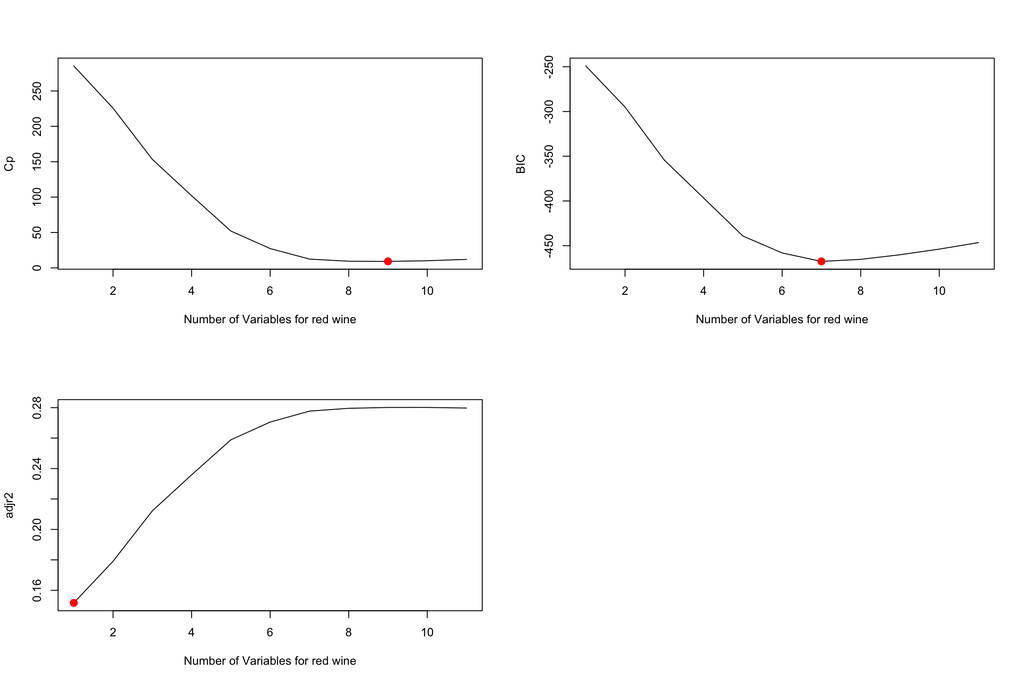

```r
par(mfrow = c(2, 2))
reg.summary_red <- summary (regfit.full_red)
plot(reg.summary_red$cp, xlab = "Number of Variables for red wine", ylab = "Cp", type = "l")
points(which.min(reg.summary_red$cp), reg.summary_red$cp[which.min(reg.summary_red$cp)], col = "red", cex = 2,
pch = 20)


plot(reg.summary_red$bic, xlab = "Number of Variables for red wine", ylab = "BIC", type = "l")
points(which.min(reg.summary_red$bic), reg.summary_red$bic[which.min(reg.summary_red$bic)], col = "red", cex = 2,
pch = 20)

plot(reg.summary_red$adjr2, xlab = "Number of Variables for red wine", ylab = "adjr2", type = "l")
points(which.min(reg.summary_red$adjr2), reg.summary_red$adjr2[which.min(reg.summary_red$adjr2)], col = "red", cex = 2,
pch = 20)
```

The below charts indicate the mentioned appraoches for the white wine data set:

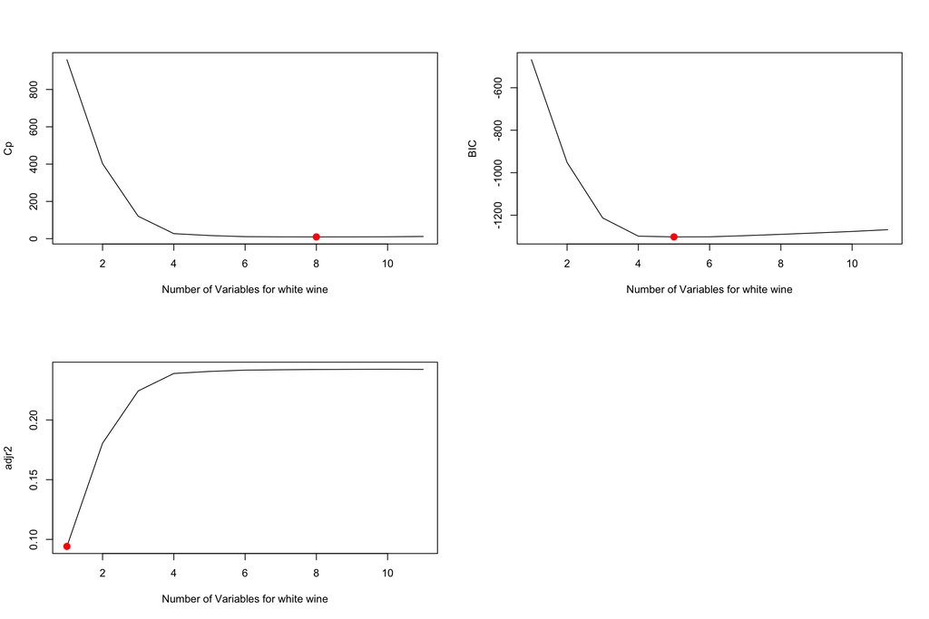

```r
par(mfrow = c(2, 2))
reg.summary_white <- summary (regfit.full_white)
plot(reg.summary_white$cp, xlab = "Number of Variables for white wine", ylab = "Cp", type = "l")
points(which.min(reg.summary_white$cp), reg.summary_white$cp[which.min(reg.summary_white$cp)], col = "red", cex = 2,
pch = 20)


plot(reg.summary_white$bic, xlab = "Number of Variables for white wine", ylab = "BIC", type = "l")
points(which.min(reg.summary_white$bic), reg.summary_white$bic[which.min(reg.summary_white$bic)], col = "red", cex = 2,
pch = 20)

plot(reg.summary_white$adjr2, xlab = "Number of Variables for white wine", ylab = "adjr2", type = "l")
points(which.min(reg.summary_white$adjr2), reg.summary_white$adjr2[which.min(reg.summary_white$adjr2)], col = "red", cex = 2,
pch = 20)
```